# 231b Section 2

Natalia Garbiras-Díaz nataliagarbirasdiaz+231b@berkeley.edu

January 27, 2016

# Today (section material from Spring 2016)

**1. Sampling with vs without replacement: Variance of the sample mean**

**2. The bootstrap**

- 2a. CLT: Distribution of the bootstap mean as a function of sample size
- 2b. Comparing the estimated SE using the analytic formula and the boostrap

**3. Standard error for the difference in means**

**4. Hypothesis testing**

- 4a. T-test
- 4b. Randomization inference

# 1. Sampling with vs without replacement: the variance of the sample mean

Last week, we talked about the expected value of the mean and wrote a simulation to show that it is an unbiased estimate for the population mean. Is this true if we are sampling with replacement? Without?

In lecture on Monday, we talked about the variance of the sample mean sampling with and without replacement.

- Are they the same? If not, how does one compare to the other?
- How could we write a simulation to answer this question?

First we need a box to sample from. We will create two different boxes, one with some “Bill Gates” in it.

```r
pop1 <- rnorm(50, 0, 5) # no outliers
pop2 <- c(rnorm(48, 0, 5), 8, 11) # two outliers
```

Let’s find the average of each box

```r
apply(cbind(pop1, pop2), 2, FUN=mean)
```

```
##       pop1       pop2
## -1.2419780  0.4113159
```

- We will sample 25 units from each population with and without replacement
- We will repeat this process 10,000 times

```r
sample_means <- matrix(NA, 10000, 4)

for (i in 1:10000){
  sample_means[i,] <- c(mean(sample(pop1, 25, replace=T)),
                        mean(sample(pop1, 25, replace=F)),
                        mean(sample(pop2, 25, replace=T)),
                        mean(sample(pop2, 25, replace=F)))
}

head(sample_means)
```

```
##             [,1]       [,2]        [,3]        [,4]
## [1,]  0.15752192 -0.8935927  0.30392963 -0.56009756
## [2,] -1.54421334 -0.8233979  0.53411446  0.96002813
## [3,] -2.72650162 -2.5562307 -0.01985295  0.06899382
## [4,] -3.19409287 -0.3365823  0.01621185  0.86016880
## [5,] -0.07978586 -1.5521258  0.51403735 -0.29535114
## [6,] -0.97675038 -1.5282102  0.61841025  1.21862595
```

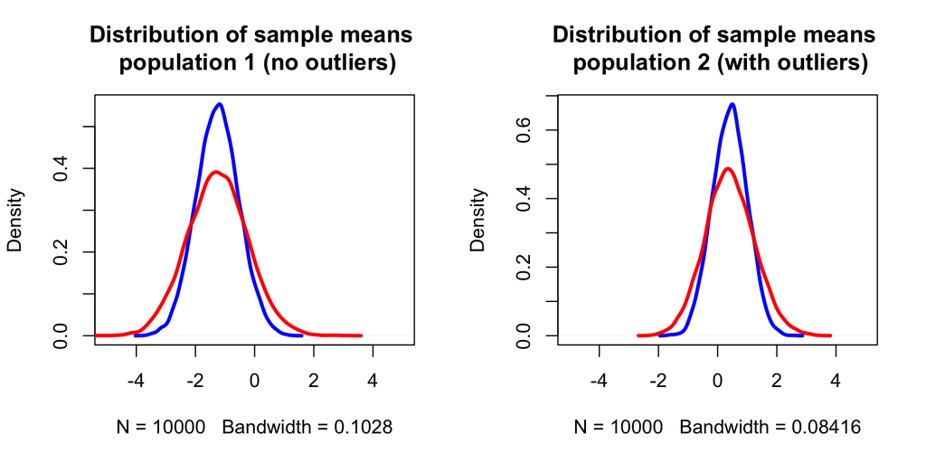

Blue = sampling without replacement, Red = sampling with replacement

```r
apply(sample_means, 2, FUN=mean)
```

```
##    pop1_with pop1_without    pop2_with pop2_without
##   -1.2516985   -1.2526821    0.4137197    0.4144782
```

```r
apply(sample_means, 2, FUN=var)
```

```
##    pop1_with pop1_without    pop2_with pop2_without
##    1.0364124    0.5197722    0.6958838    0.3481313
```

# 2. The bootstrap

For this problem, we are going to use the sample values for the co-ethnic cousin (treatment) condition ($treat\_assign=1$). This will be our box, the “bootstrap population”.

Let’s plot the empirical distribution of responses in the treatment group.

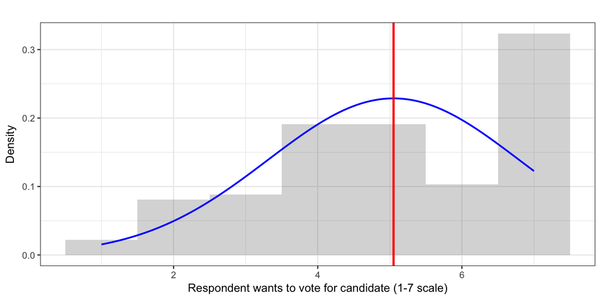

We will use the bootstrap to investigate the properties of different sampling procedures.

1. Take the sample values as the population;
2. Draw a sample from this population (box) with replacement, using the sampling procedure we want to analyze; save the sample statistics (e.g. the mean). This is a “bootstrap replicate.”
3. Repeat step (2) many times (say, 10,000 times).
4. Plot the distribution of the saved statistics across all the bootstrap replicates. This gives us a good glimpse of the sampling distribution of the statistic of interest.

```r
# We first need to define the number of units we will draw from the box
# (with replacement).
# For the first example, let's take N=5
N <- 5

# If we wanted to do step (2) once, we would sample from the box N times with replacement
boot_sample <- sample(box$box, N, replace=T)
# And then take the statistic of interest for this bootstrap sample, here the mean.
mean(boot_sample)
```

```
## [1] 5
```

But we want to do this many times— 10,000 times! What can we do?

We write a for loop that repeats this sampling procedure 10,000 times:

```r
boot_reps <- 10000 # number of bootstrap replicates we will repeat step (2) for
boot_mean <- NA # placeholder vector for the results

for (i in 1:boot_reps){
  boot_sample <- sample(box$box, N, replace=T)
  boot_mean[i] <- mean(boot_sample)
}
```

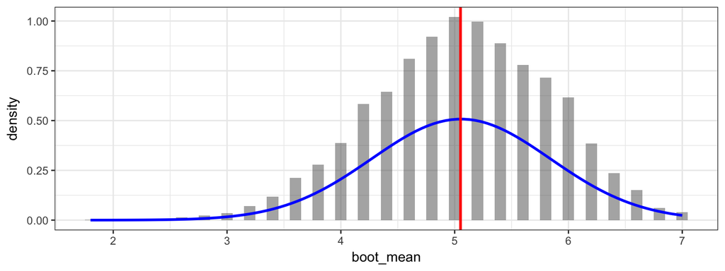

We will now repeat this procedure, varying the size of the bootstrap sample, several times. We can write a function which does the bootstraps, and plots a histogram for their mean.

Our function will require - the data, - the number of bootstrap replicates, - the number of observations to be sampled from the box in each replicate - the binwidth to be used for the histogram.

It will sample N units with replacement and get the mean for that sample

```r
bootstrap_mean <- function(data, replicates=10000, N, bin, title="",
                           xlab="", ylab="", xmax, xmin){

  boot_mean <- NA #plaaceholder vector
  for (i in 1:replicates){
    # we sample N units from the box with replacement
    boot_sample <- sample(data, N, replace=T)
    # and save their mean
    boot_mean[i] <- mean(boot_sample)
  }

  m <- ggplot(as.data.frame(boot_mean), aes(x=boot_mean))
  # First we plot a histogram with the results
  m + geom_histogram(aes(y = ..density..), alpha=.5, binwidth=bin) +
    # and overlay a line with the density of a normal distribution with mean equal to the mean
    # of the bootstrap means and sd equal to the sd of the bootstrap means.
    stat_function(fun=dnorm,
                  args=list(mean=mean(boot_mean), sd=sd(boot_mean)), col="blue", size=1) +
    # and we add a vertical line for the mean of the box
    geom_vline(xintercept = mean(box$box), col="red", size=1) +
    # limits for x axis
    scale_x_continuous(limits = c(xmin, xmax)) +
    # and labels
    labs(title=title,  x=xlab, y=ylab) + theme_bw()
}
```

Now we will run the bootstrap varying N.

**N = 5**

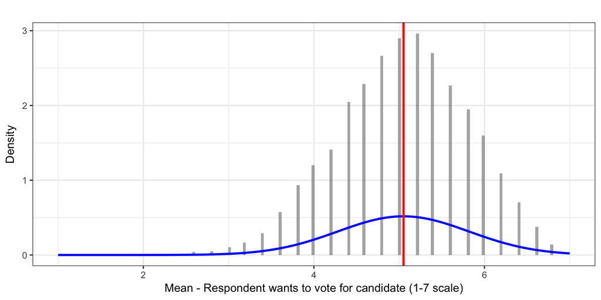

```r
bootstrap_mean(data=box$box, replicates=10000, N=5, bin=.035,
               # title="N=5",
               xmin=1, xmax=7,
               xlab="Mean - Respondent wants to vote for candidate (1-7 scale)",
               ylab="Density")
```

**N = 25**

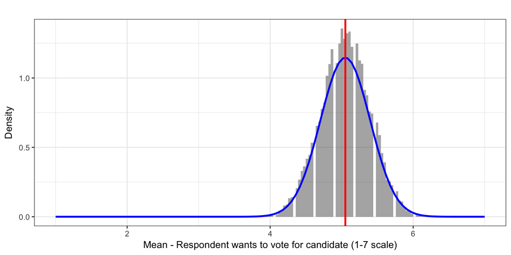

```r
bootstrap_mean(data=box$box, replicates=10000, N=25, bin=.035,
               # title="N=25",
               xmin=1, xmax=7,
               xlab="Mean - Respondent wants to vote for candidate (1-7 scale)",
               ylab="Density")
```

**N = 100**

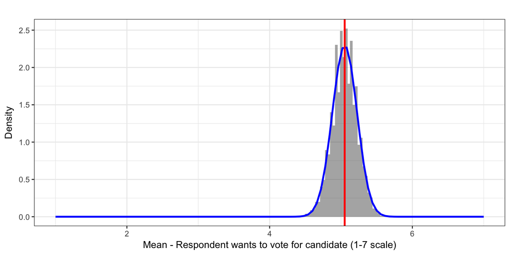

```r
bootstrap_mean(data=box$box, replicates=10000, N=100, bin=.035,
               # title="N=100",
               xmin=1, xmax=7,
               xlab="Mean - Respondent wants to vote for candidate (1-7 scale)",
               ylab="Density")
```

Now, let’s compare the $\hat{SE}$ that we obtain from the analytic formula and the bootstrap:

- Recall the analytic formula of the $\hat{SE}$ for the sample mean in the treatment group:
  $$\hat{SE} = \frac{\hat{\sigma}}{\sqrt{m}}$$

```r
# We first need an unbiased estimator of the variance:
est.var.analy <- var(box) # denominator : (n-1)
# Then we plug it into the analytic formula of the SE (est.)
se_analy = sqrt(est.var.analy/(nrow(box)))
se_analy
```

```
##           box
## box 0.1495527
```

- Now, how can we get the SE from the bootstrap replicates?

```r
# Bootstrap:
N<-136
replicates <- 10000
boot_mean <- NA #plaaceholder vector

  for (i in 1:replicates){
    # we sample N units from the box with replacement
    boot_sample <- sample(box$box, N, replace=T)
    # and save their mean
    boot_mean[i] <- mean(boot_sample)
  }

boot.se<-sd(boot_mean)
ses<- c(se_analy,boot.se)
names(ses)<-c("Analytic Formula","Bootstrap")
ses
```

```
## Analytic Formula        Bootstrap
##        0.1495527        0.1479125
```

In this case, the bootstrap gives the same answer as the analytic formula—because the latter is correct for i.i.d. sampling, and here we are building i.i.d. sampling into the bootstrap routine.

# 3. Standard error for the difference in means

```r
#Gerber and Green (2012); Chattopadhyay and Duflo (2004)

# the data
gg_data <- as.data.frame(cbind(c(10,15,20,20,10,15,15),
                               c(15,15,30,15,20,15,30)))
names(gg_data) <- c("Y_i0", "Y_i1")
```

```r
# generating empty dataframe to put the results
ate <- as.data.frame(matrix(NA, 10000, 2))
names(ate) <- c("estimated_ate", "estimated_se_ate")

# sampling
for (i in 1:10000){

  # generating treatment vector for this replicate
  gg_data$treat <- 0
  gg_data$treat[sample(1:7, 2, replace=F)]  <- 1

  treat_mean <- mean(gg_data$Y_i1[gg_data$treat==1])
  treat_var <- var(gg_data$Y_i1[gg_data$treat==1])

  control_mean <- mean(gg_data$Y_i0[gg_data$treat==0])
  control_var <- var(gg_data$Y_i0[gg_data$treat==0])

  ate[i,1] <- treat_mean - control_mean
  ate[i,2] <- sqrt(treat_var/2 + control_var/5)
}
```

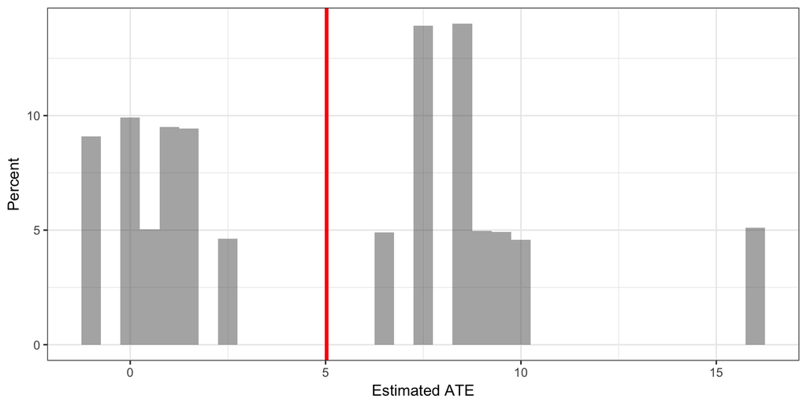

What should be the title of this figure?

# 4. Hypothesis testing

```r
# generating treatment vector for a given experiment
gg_data$treat <- c(1, 0, 0, 0, 0, 0, 1)

# getting observed outcomes
gg_data$observed <- ifelse(gg_data$treat==1, gg_data$Y_i1, gg_data$Y_i0)

# ate
ATE <- mean(gg_data$observed[gg_data$treat==1]) - mean(gg_data$observed[gg_data$treat==0])
ATE
```

```
## [1] 6.5
```

- What is a p-value?

# 4a. T-test

```r
treated <- gg_data$observed[gg_data$treat==1]
treated
```

```
## [1] 15 30
```

```r
var1 <- sum((treated - mean(treated))^2) / (length(treated) - 1)
var1
```

```
## [1] 112.5
```

```r
not_treated <- gg_data$observed[gg_data$treat==0]
not_treated
```

```
## [1] 15 20 20 10 15
```

```r
var0 <- sum((not_treated - mean(not_treated))^2) / (length(not_treated) - 1)
var0
```

```
## [1] 17.5
```

```r
estimated_se <- sqrt(var1/length(treated) + var0/length(not_treated))
estimated_se # Why is this number different from 7.75 (the number in the lecture slides)?
```

```
## [1] 7.729812
```

```r
# rounding error!
```

```r
# converting to standard units
t_stat <- (ATE - 0) / estimated_se
t_stat
```

```
## [1] 0.8409001
```

```r
# To be able to get the right Student t Distribution, we need to calculate
# the degrees of freedom (Satterthwaite)
df <- (var1/length(treated) + var0/length(not_treated))^2 /
           ((var1/length(treated))^2 / (length(treated) - 1) +
           (var0/length(not_treated))^2 / (length(not_treated) - 1))
df
```

```
## [1] 1.127225
```

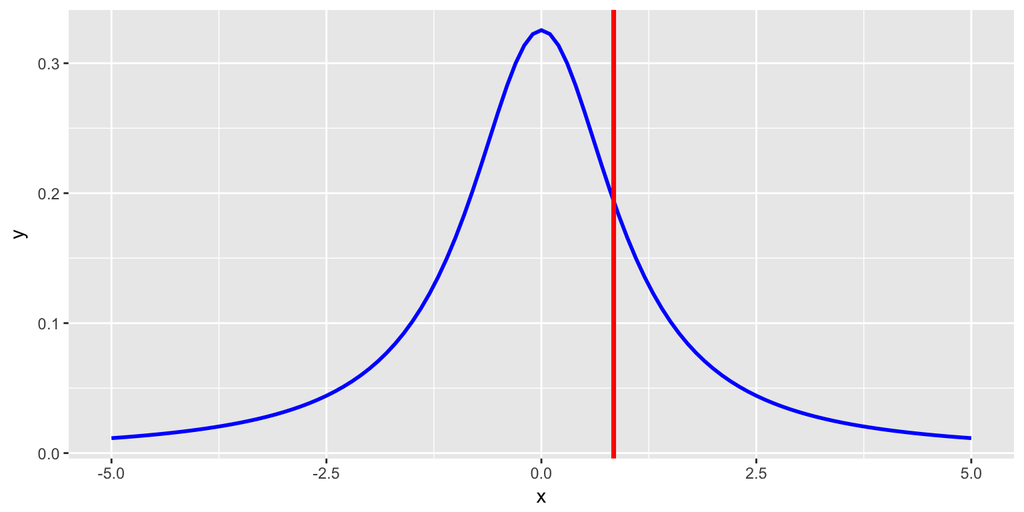

```r
# Overlaying the t_stat to the student t distribution
ggplot(data.frame(x = c(-5, 5)), aes(x)) +
  stat_function(fun=dt, args=list(df=df, ncp=0), col="blue", size=1) +
  geom_vline(xintercept = mean(t_stat), col="red", size=1.25)
```

```r
# One tailed p-value
pt(t_stat, df=df, ncp=0, lower.tail=F)
```

```
## [1] 0.2708243
```

```r
# Two tailed p-value
pt(-t_stat, df=df, ncp=0, lower.tail=T) + pt(t_stat, df=1.12, ncp=0, lower.tail=F)
```

```
## [1] 0.5419946
```

# 4b. Randomization inference

To get all the possible treatment vectors, we will generate 10000 differente ones…

```r
fake_treats <- matrix(NA, 10000, 7)
for (i in 1:10000){
fake_treats[i,] <- sample(gg_data$treat, 7, replace=F)
}
```

… and then only keep the unique ones

```r
fake_treats <- unique(fake_treats)
```

Now we need to calculate the ATE for each of these possible randomizations. For that, we will need a loop

```r
rand_ate <- NA # placeholder vector for results

for (i in 1:nrow(fake_treats)){ # for each of the fake treatment vectors

  mean_treat <- mean(gg_data$observed[fake_treats[i,]==1])

  mean_control <- mean(gg_data$observed[fake_treats[i,]==0])

  # calculating ATE for this randomization
  rand_ate[i] <- mean_treat - mean_control

}
```

Now we can plot the distribution of the randomization ATEs

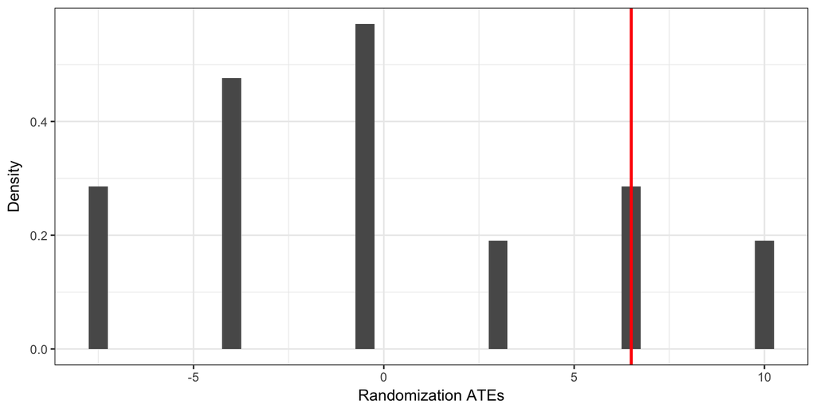

Distribution of randomization ATEs

And we can get the p-value

```r
# One tailed
sum(rand_ate>=ATE)/length(rand_ate)
```

```
## [1] 0.2380952
```

```r
# Two tailed
sum(abs(rand_ate)>=ATE)/length(rand_ate)
```

```
## [1] 0.3809524
```